# Washington DC Transit Oriented Development

Jonathan Manurung

September, 2023

# What is Transit Oriented Development?

Transit-Oriented Development (TOD) describe by the United States Department of Transport as the dense, walkable, and mixed-use spaces near transit, intended to bring connectivity between transit services and the household nearby. TOD recommends increasing housing and amenity around transit station such as rail, subway, bus, etc. High density around TOD will promote efficiency in operating the transit system. TOD is also important for land value capitalization because its relation to rent price and property tax return. Interestingly, most transit systems in many major city are remarkably inefficient.

TOD analysis in Washington D.C, a city with an extensive public transportation network, examines whether residents are willing to pay a premium to live in TOD areas, reflecting the benefits of proximity to transit, reduced commuting costs and time to access their office or any other amenities.

# Relating Washington D.C. Census Tracts and Metro Stations in space

To understand whether TOD areas are valued more than non-TOD areas, appropriate methodology is needed. Relating the census variables and metro stations in space is necessary to examine the relationship.

To get better understanding on how TOD and related census characteristic have evolved over time, data from two points are used: 2009 vs 2019. This comparison will allow us to observe trends and changes, identify areas of growth or decline, and make relative comparisons. Census variables that linked to residents willingness to pay for TOD are, median rent price, median household income, percentage of public transit user, and percentage of non family households in the surrounding area.

Closeness is relative and instinctual to human beings. In TOD analysis, close is defined as area within a half mile (2,640 ft.) of a single transit station.

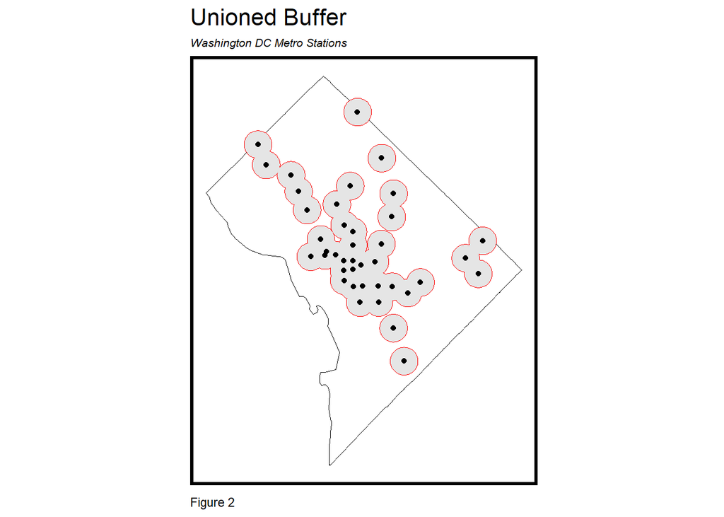

```r
metro_stations_buffers <-
  rbind(
    st_buffer(metro_stations_exp, 2640) %>%
      mutate(Legend = "Buffer") %>%
      select(Legend),
    st_union(st_buffer(metro_stations_exp, 2640)) %>%
      st_sf() %>%
      mutate(Legend = "Unioned Buffer"))

ggplot() +
  geom_sf(data= st_union(allDC), fill = NA, colour = "black") +
  geom_sf(data=metro_stations_buffers, color ="red") +
  geom_sf(data=metro_stations_exp, show.legend = "point") +
  labs(title = "Unioned Buffer", subtitle = "Washington DC Metro Stations", caption = "Figure 2")+
  mapTheme()+
  theme(plot.subtitle = element_text(size = 8))
```

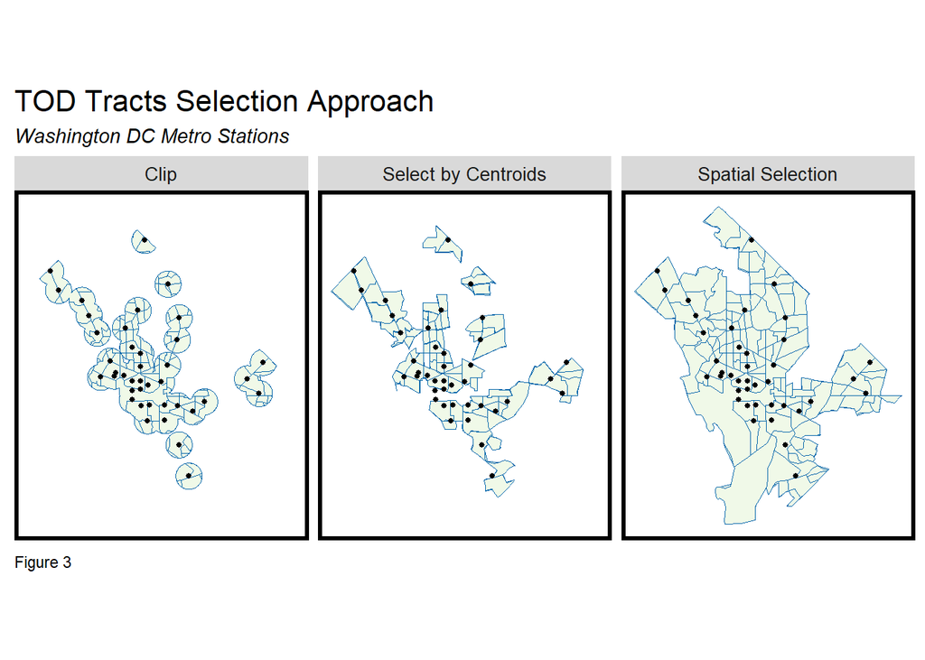

```r
buffer <- filter(metro_stations_buffers, Legend=="Unioned Buffer")

clip <-
  st_intersection(buffer, allDC) %>%
    select(geometry) %>%
    mutate(Selection_Type = "Clip")

selection <-
  allDC[buffer,] %>%
    select(geometry) %>%
    mutate(Selection_Type = "Spatial Selection")

selectCentroids <-
  st_centroid(allDC)[buffer,] %>%
    st_drop_geometry() %>%
    left_join(select(allDC, GEOID)) %>%
    st_sf() %>%
    dplyr::select(geometry) %>%
    mutate(Selection_Type = "Select by Centroids")

intersections <- rbind(clip, selection, selectCentroids)

ggplot() +
  geom_sf(data=intersections, fill = "#f0f9e8", color = "#0868ac") +
  geom_sf(data=metro_stations_exp, show.legend = "point", color = "black", size = 1) +
  scale_fill_viridis_c() +
  facet_wrap(~Selection_Type) +
  labs(title = "TOD Tracts Selection Approach", subtitle = "Washington DC Metro Stations", caption = "Figure 3")+
  mapTheme()+
  theme(
    strip.text.x = element_text(size = 10))
```

Select by Centroid is the most complicated and detailed approach, as it selects all the tract centroids that intersect the buffer area. It also capture a concise set of tracts without altering geometries, making it a more reliable option for TOD and non-TOD tract selection (see Figure 4)

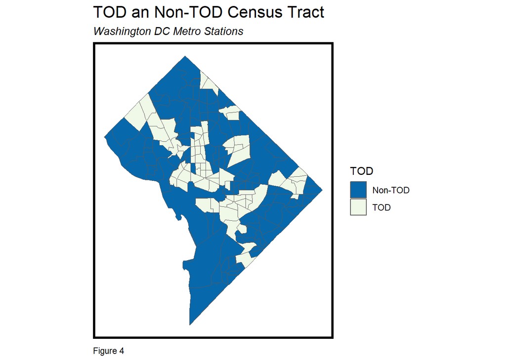

```r
allDCdat <-
  rbind(
    st_centroid(allDC)[buffer, ] %>%
      st_drop_geometry() %>%
      left_join(allDC) %>%
      st_sf() %>%
      mutate(TOD = "TOD"),
    st_centroid(allDC)[buffer, op = st_disjoint] %>%
      st_drop_geometry() %>%
      left_join(allDC) %>%
      st_sf() %>%
      mutate(TOD = "Non-TOD")
  )

ggplot() +
  geom_sf(data=allDCdat, aes(fill = TOD)) +
  scale_fill_manual(values = c("TOD" = "#f0f9e8", "Non-TOD" = "#0868ac")) +
  labs(title = "TOD an Non-TOD Census Tract", subtitle = "Washington DC Metro Stations", caption = "Figure 4")+
  mapTheme()
```

Four census variables that selected earlier as indicators, are plotted across time and space into multiple TOD indicator maps to visualize the comparison between TOD and non-TOD census tracts (see Figure 5)

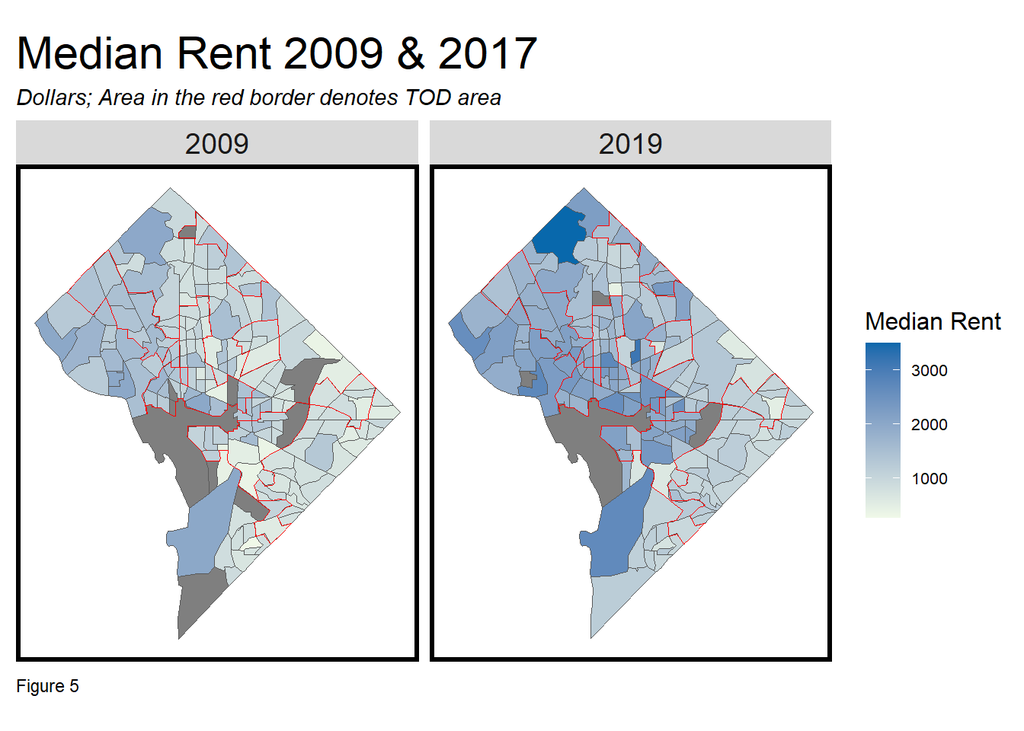

```r
TOD_tracts <- allDCdat %>%
  filter(TOD == "TOD")

TOD_bound <- st_union(TOD_tracts)

Median_Rent <-
  ggplot()+
  geom_sf(data=allDC, aes(fill = Medgrosrent))+
  geom_sf(data = TOD_bound, fill = NA, color = "red", size = 0.5) +
  scale_fill_gradient(low = "#f0f9e8", high ="#0868ac", name = "Median Rent")+
  labs(title = "Median Rent 2009 & 2017", subtitle = "Dollars; Area in the red border denotes TOD area ", caption = "Figure 5" )+
  facet_wrap(~year)+
  mapTheme()+
  theme(plot.title = element_text(size = 22),
        legend.title = element_text(size = 12),
        legend.text = element_text(size = 8))

Median_Household_Income <-
  ggplot()+
  geom_sf(data=allDC, aes(fill = Medhhinc))+
  geom_sf(data = TOD_bound, fill = NA, color = "red", size = 0.5) +
  scale_fill_gradient(low = "#f0f9e8", high ="#0868ac", name = "Median Household Income")+
  labs(title = "Median Household Income 2009 & 2017", subtitle = "Dollars; Area in the red border denotes TOD area ", caption = "Figure 2.1" )+
  facet_wrap(~year)+
  mapTheme()+
  theme(plot.title = element_text(size = 22),
        legend.title = element_text(size = 12),
        legend.text = element_text(size = 8))

Percent_Public_Transport_User <-
  ggplot()+
  geom_sf(data=allDC, aes(fill = pctpubtransuser))+
  geom_sf(data = TOD_bound, fill = NA, color = "red", size = 0.5) +
  scale_fill_gradient(low = "#f0f9e8", high ="#0868ac", name = "Public Transport User")+
  labs(title = "Public Transport User 2009 & 2017", subtitle = "Percent; Area in the red border denotes TOD area ", caption = "Figure 2.1" )+
  facet_wrap(~year)+
  mapTheme()+
  theme(plot.title = element_text(size = 22),
        legend.title = element_text(size = 12),
        legend.text = element_text(size = 8))

Percent_Non_Family_Household <-
  ggplot()+
  geom_sf(data=allDC, aes(fill = pctnonfamhh))+
  geom_sf(data = TOD_bound, fill = NA, color = "red", size = 0.5) +
  scale_fill_gradient(low = "#f0f9e8", high ="#0868ac", name = "Non Family Household")+
  labs(title = "Non Family Household 2009 & 2017", subtitle = "Percent; Area in the red border denotes TOD area ", caption = "Figure 5" )+
  facet_wrap(~year)+
  mapTheme()+
  theme(plot.title = element_text(size = 22),
        legend.title = element_text(size = 12),
        legend.text = element_text(size = 8))

print(Median_Rent)
```

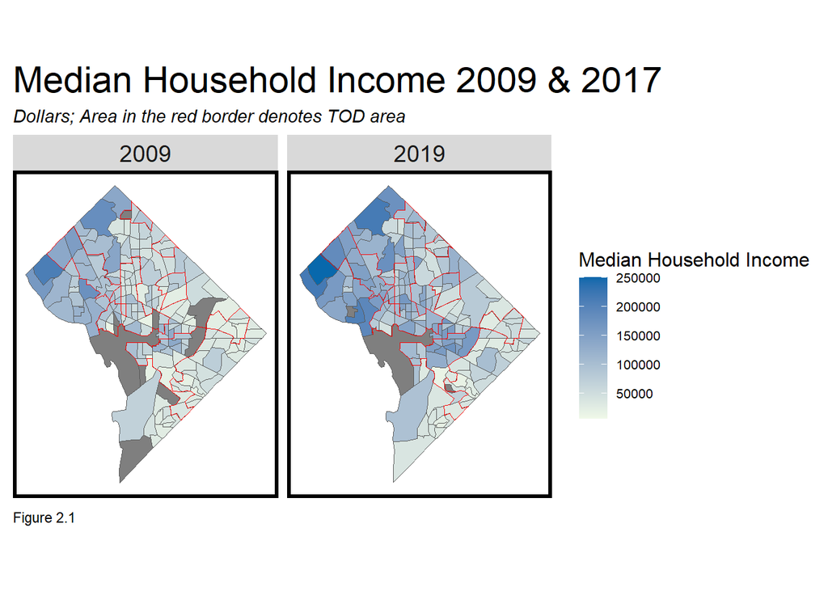

```r
print(Median_Household_Income)
```

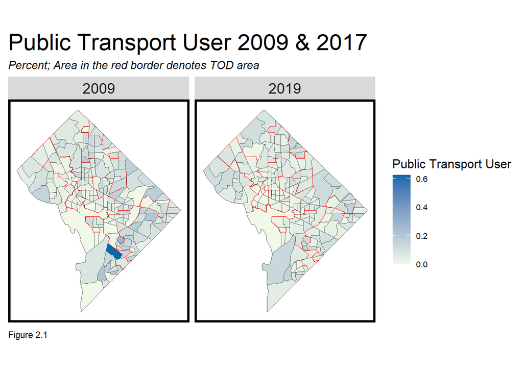

```r
print(Percent_Public_Transport_User)
```

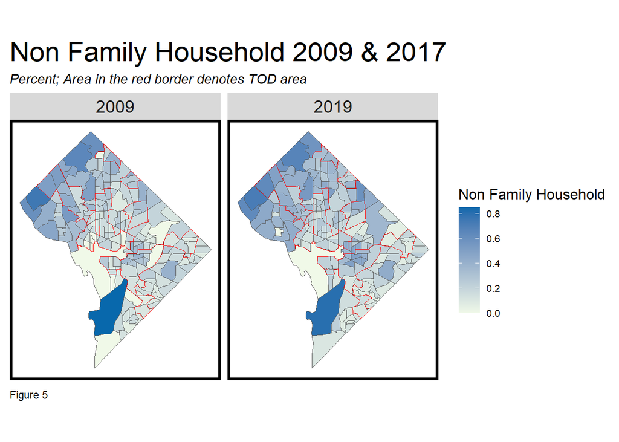

```r
print(Percent_Non_Family_Household)
```

While the maps illustrate changes across all census tracts, grouped bar plot and table summarized key indicators for TOD and non-TOD census tracts in 2009 and 2019 (see Figure 6 and Table 1)

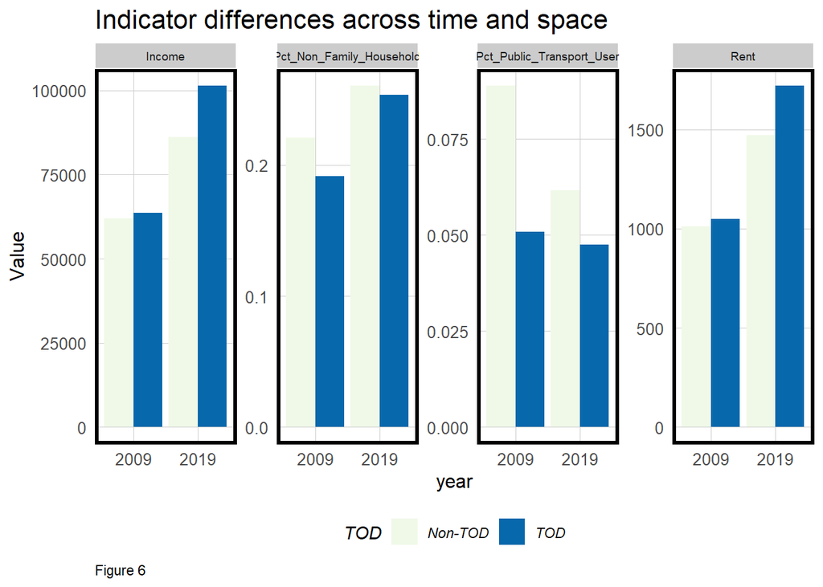

```r
allDC.Summary <-
  st_drop_geometry(allDCdat) %>%
    group_by(year, TOD) %>%
    summarize(Rent = mean(Medgrosrent, na.rm = T),
              Income = mean(Medhhinc, na.rm = T),
              Pct_Public_Transport_User = mean(pctpubtransuser, na.rm = T),
              Pct_Non_Family_Household = mean(pctnonfamhh, na.rm = T))

allDC.Summary %>%
  gather(Variable, Value, -year, -TOD) %>%
  ggplot(aes(year, Value, fill = TOD)) +
    geom_bar(stat = "identity", position = "dodge") +
    facet_wrap(~Variable, scales = "free", ncol=5) +
    scale_fill_manual(values = c("#f0f9e8", "#0868ac")) +
    labs(title = "Indicator differences across time and space", caption = "Figure 6") +
    plotTheme() + theme(legend.position="bottom", strip.text.x = element_text(size = 7))
```

```r
allDC.Summary %>%
  unite(year.TOD, year, TOD, sep = ": ", remove = T) %>%
  gather(Variable, Value, -year.TOD) %>%
  mutate(Value = round(Value, 2)) %>%
  spread(year.TOD, Value) %>%
  kable() %>%
    kable_styling() %>%
    footnote(general_title = "\n",
             general = "Table 1")
```

| Variable | 2009: Non-TOD | 2009: TOD | 2019: Non-TOD | 2019: TOD |
| --- | --- | --- | --- | --- |
| Income | 61998.86 | 63546.57 | 86196.55 | 101401.36 |
| Pct_Non_Family_Household | 0.22 | 0.19 | 0.26 | 0.25 |
| Pct_Public_Transport_User | 0.09 | 0.05 | 0.06 | 0.05 |
| Rent | 1012.10 | 1048.63 | 1470.50 | 1721.03 |

Table 1

The grouped bar plots and table make it easier to observe that rent prices, median household income, and percent of non-family household in both TOD and non-TOD census tracts were increasing during the period of 2009 to 2019. They also capture the decrease of percent of public transportation user in both TOD and non-TOD census tracts

```r
tmap_mode("view")

metro_stations$station_id <- seq_len(nrow(metro_stations))
TOD_tracts <- st_intersection(allDC, metro_stations)

# Population
TOD_agg_pop <- TOD_tracts %>%
  st_set_geometry(NULL) %>%
  group_by(station_id, year) %>%
  summarise(total_population = sum(TotalPop, na.rm = TRUE))

stations_2009 <- metro_stations %>%
  left_join(TOD_agg_pop %>% filter(year == 2009), by = "station_id")

Pop_Grad_Map_2009 <-
  tm_shape(stations_2009) +
  tm_bubbles(col = "red",
             size = "total_population",
             border.col = "black",
             border.lwd = 1,
             scale = 2,
             title.size = "Population 2009")

stations_2019 <- metro_stations %>%
  left_join(TOD_agg_pop %>% filter(year == 2019), by = "station_id")


Pop_Grad_Map_2019 <-
  tm_shape(stations_2019) +
  tm_bubbles(col = "blue",
             size = "total_population",
             border.col = "black",
             border.lwd = 1,
             scale = 2,
             title.size = "Population 2019")

# Rent
TOD_agg_rent <- TOD_tracts %>%
  st_set_geometry(NULL) %>%
  group_by(station_id, year) %>%
  summarise(median_rent = sum(Medhhinc, na.rm = TRUE))

stations_2009 <- metro_stations %>%
  left_join(TOD_agg_rent %>% filter(year == 2009), by = "station_id")

Rent_Grad_Map_2009 <-
  tm_shape(stations_2009) +
  tm_bubbles(col = "red",
             size = "median_rent",
             border.col = "black",
             border.lwd = 1,
             scale = 2,
             title.size = "Rent 2009")

stations_2019 <- metro_stations %>%
  left_join(TOD_agg_rent %>% filter(year == 2019), by = "station_id")


Rent_Grad_Map_2019 <-
  tm_shape(stations_2019) +
  tm_bubbles(col = "blue",
             size = "median_rent",
             border.col = "black",
             border.lwd = 1,
             scale = 2,
             title.size = "Rent 2019")

tmap_arrange(Pop_Grad_Map_2009, Pop_Grad_Map_2019, Rent_Grad_Map_2009, Rent_Grad_Map_2019, ncol = 2, nrow = 2)
```

[interactive chart not shown]

# Are Washington D.C.’s Residents Willing to Pay More for TOD?

There is insufficient evidence to draw firm conclusions regarding whether residents are willing to pay more for TOD areas. It is critical to understand how omitted variables affect the relevant spatial process and ultimately, the results of an analysis. The increase of median rent price in the area from 2009 to 2019 may appear to reflect residents’ willingness to pay more for TOD areas. However, when considered alongside increasing household incomes, such increases can also be seen as a natural outcome, reflecting general price growth and inflation.

Declining percentage of public transport user both in TOD and non-TOD area explains that residents are not relying on public transport for commuting. Giving the assumption that accessibility to public transport may not something that the residents are looking for when they decided to live in TOD area. It could be that they pay more for other amenities in neighborhoods that happen to also be transit-rich.

Function between mean rent and distance to subway stations does not indicate that properties closest to the subway are more expensive than the further properties (see Figure 7)

Further study is necessary to explore the determinants of residential choice in TOD areas, including the role of transit accessibility, housing costs, and demographic factors.

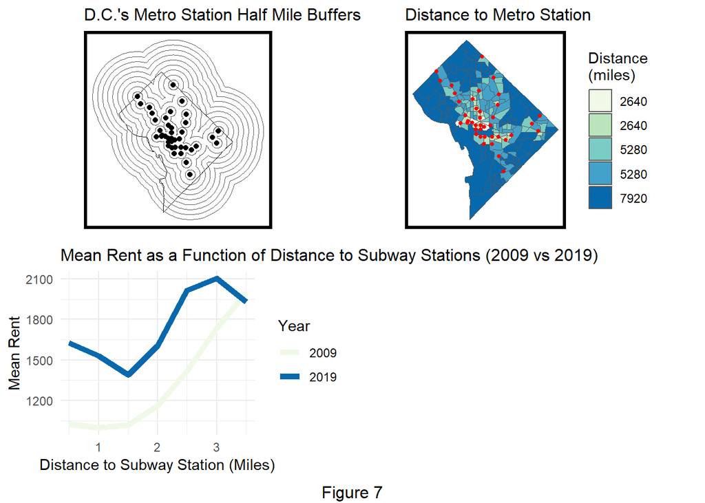

```r
TOD_buffers <-
  multipleRingBuffer(st_union(metro_stations),23760,2640)

halfmile_buf <-
  ggplot()+
  geom_sf(data= st_union(allDC), fill = NA, colour = "black") +
  geom_sf(data = metro_stations, show.legend = "point" )+
  geom_sf(data = TOD_buffers, fill =NA, colors ="black")+
  labs(title = "D.C.'s Metro Station Half Mile Buffers")+
  mapTheme()+
  theme(plot.title = element_text(size = 12))


tracts_buffered <- st_join(allDC, TOD_buffers, join = st_intersects)

tracts_distance <-
  ggplot() +
  geom_sf(data = tracts_buffered, aes(fill = q5(distance))) +
  geom_sf(data = metro_stations, color = "red", size = 1) +
  scale_fill_manual(values = palette5,
                    labels = qBr(tracts_buffered, "distance"),
                    name = "Distance\n(miles)") +
  labs(title = "Distance to Metro Station") +
  mapTheme()+
  theme(plot.title = element_text(size = 12))

rent_by_distance <- tracts_buffered %>%
  mutate(distance_miles = distance / 5280) %>%
  group_by(year, distance_miles) %>%
  summarise(mean_rent = mean(Medgrosrent, na.rm = TRUE)) %>%
  filter(!all(is.nan(mean_rent))) %>%
  ungroup()%>%
  group_by(distance_miles) %>%
  filter(all(!is.nan(mean_rent))) %>%  # keep only distances where both years have data
  ungroup()

rent_dist_line <-
  ggplot() +
  geom_line(data = rent_by_distance, aes(x = distance_miles, y = mean_rent, color = factor(year)), size = 2) +
  labs(
    x = "Distance to Subway Station (Miles)",
    y = "Mean Rent",
    color = "Year",
    title = "Mean Rent as a Function of Distance to Subway Stations (2009 vs 2019)"
  ) +
  scale_color_manual(values = c("2009" = "#f0f9e8", "2019" = "#0868ac")) +
  theme_minimal() +
  theme(
    plot.title = element_text(size = 12)
  )


grid.arrange(halfmile_buf, tracts_distance,rent_dist_line, ncol = 2,
bottom = textGrob("Figure 7", gp = gpar(fontsize = 12)))
```